# PART 1: DATA INVESTIGATION

## The story:

Recently at AAVAIL there has been discussion among management about different approaches to revenue generation. AAVAIL launched using a tiered, subscription-based service which showed promise, but conversations with users, especially those outside of US markets, prompted an experiment using an à la carte approach. This experiment was carried out mostly outside of the US and there are now a couple of years of data with a few thousand active users. The data are transaction-level purchases across 38 different countries and are invoiced in batches. Management has nearly decided to make the switch to the new model, but they find it difficult to predict monthly revenue. They have asked you to create a service that, at any point in time, will predict the revenue for the following month. They have also asked that the service be given the ability to project revenue for a specific country. To keep the development time reasonable you have been advised to limit your model to the ten countries with the most revenue.

You have spoken at length with the managers who will be the end users of this model and they are confident that this product will have a meaningful business impact. Currently, these managers are using their own methods to predict revenue, but they have come to feel that they are spending too much time on this and their lack of expertise in data science means their predictions are not as accurate as they would like. The management team expects to spend less time creating their own projection models, and they expect the new results to be more accurate. They have assured you that well-projected numbers will help stabilize staffing and budget projections which will have a beneficial ripple effect throughout the company.

If the current month is April your model will need to predict the revenue for May. If you decide to use a supervised learning approach to this prediction problem, we will provide some guidance with respect to feature engineering. We will also talk about the use of time-series modeling approaches, but both of these topics will be in the next part of the case study. First, you need to understand the business scenario in the context of available data and carry out an investigation. The goals of this part of the case study are below.

## Tasks

- Assimilate the business scenario and articulate testable hypotheses.
- State the ideal data to address the business opportunity and clarify the rationale for needing specific data.
- Create a python script to extract relevant data from multiple data sources, automating the process of data ingestion.
- Investigate the relationship between the relevant data, the target and the business metric.
- Articulate your findings using a deliverable with visualizations.

## 1. Business scenario and testable hypotheses.

Assimilate the business scenario and articulate testable hypotheses.

Previous subcription type: tiered.

Potential approach: à la carte

RQ: To what extend could à la carte subscription approach help improve revenues?

Hypothesis: We can use a prediction model using transaction historical data to identify the impact of the new subscription approach in the revenue.

## 2. Desirable data.

State the ideal data to address the business opportunity and clarify the rationale for needing specific data.

Data available:

- Transaction-level purchases
- In 38 countries
- In montly batches (11/2017 to 07/2019)

Features of interest:

- Customer ID
- Country
- Purchases
- Subscription type

Objectives

1.- The managers are interested in a model that wil predict the revenue for the following month. 2.- They also asked to predict revenue for a specific country.

Only the ten countries with the most revenue should be considered for the model.

## 3. Data ingestion.

Create a python script to extract relevant data from multiple data sources, automating the process of data ingestion.

To run as a script, run command:

`!python ./scripts/cslib.py`

This creates the time-series DataFrame files in "./cs-train/ts-data" that can be imported directly (using cslib.fetch_ts function).

```python
import time, os, ast, glob, requests, json
from datetime import date

from scripts.cslib import *
from scripts.utils import *
```

```python
DATA_DIR = os.path.join(".","cs-train")
IMG_DIR = os.path.join(".","images")
MODEL_DIR = os.path.join(".","models")
LOG_DIR = os.path.join(".","logs")
```

Load data from multiple JSON files.

- Check for inconsistencies in column names in src files.
- Remove letters in `invoice` for matching.

```python
f_col_names = check_col_names(DATA_DIR, verbose=True)
f_col_names
```

```
Importing invoices-2018-01.json:
Importing invoices-2017-12.json:
Importing invoices-2019-01.json:
Importing invoices-2018-11.json:
Importing invoices-2018-07.json:
Importing invoices-2019-06.json:
Importing invoices-2019-07.json:
Importing invoices-2018-06.json:
Importing invoices-2018-10.json:
Importing invoices-2018-09.json:
Importing invoices-2019-04.json:
Importing invoices-2018-05.json:
Importing invoices-2018-12.json:
Importing invoices-2018-04.json:
Importing invoices-2019-05.json:
Importing invoices-2018-08.json:
Importing invoices-2019-02.json:
Importing invoices-2018-03.json:
Importing invoices-2017-11.json:
Importing invoices-2018-02.json:
Importing invoices-2019-03.json:
```

|  | 0 | 1 | 2 | 3 | 4 | 5 | 6 | 7 | 8 |
| --- | --- | --- | --- | --- | --- | --- | --- | --- | --- |
| invoices-2018-01.json | country | customer_id | invoice | total_price | StreamID | TimesViewed | year | month | day |
| invoices-2017-12.json | country | customer_id | invoice | total_price | stream_id | times_viewed | year | month | day |
| invoices-2019-01.json | country | customer_id | invoice | total_price | stream_id | times_viewed | year | month | day |
| invoices-2018-11.json | country | customer_id | invoice | price | StreamID | TimesViewed | year | month | day |
| invoices-2018-07.json | country | customer_id | invoice | price | StreamID | TimesViewed | year | month | day |
| invoices-2019-06.json | country | customer_id | invoice | price | stream_id | times_viewed | year | month | day |
| invoices-2019-07.json | country | customer_id | invoice | price | stream_id | times_viewed | year | month | day |
| invoices-2018-06.json | country | customer_id | invoice | price | StreamID | TimesViewed | year | month | day |
| invoices-2018-10.json | country | customer_id | invoice | price | StreamID | TimesViewed | year | month | day |
| invoices-2018-09.json | country | customer_id | invoice | price | StreamID | TimesViewed | year | month | day |
| invoices-2019-04.json | country | customer_id | invoice | price | stream_id | times_viewed | year | month | day |
| invoices-2018-05.json | country | customer_id | invoice | price | StreamID | TimesViewed | year | month | day |
| invoices-2018-12.json | country | customer_id | invoice | total_price | StreamID | TimesViewed | year | month | day |
| invoices-2018-04.json | country | customer_id | invoice | price | StreamID | TimesViewed | year | month | day |
| invoices-2019-05.json | country | customer_id | invoice | price | stream_id | times_viewed | year | month | day |
| invoices-2018-08.json | country | customer_id | invoice | price | StreamID | TimesViewed | year | month | day |
| invoices-2019-02.json | country | customer_id | invoice | price | stream_id | times_viewed | year | month | day |
| invoices-2018-03.json | country | customer_id | invoice | price | StreamID | TimesViewed | year | month | day |
| invoices-2017-11.json | country | customer_id | invoice | price | stream_id | times_viewed | year | month | day |
| invoices-2018-02.json | country | customer_id | invoice | price | StreamID | TimesViewed | year | month | day |
| invoices-2019-03.json | country | customer_id | invoice | price | stream_id | times_viewed | year | month | day |

```python
# Load all json formatted files into a single dataframe
run_start = time.time()

print("...fetching data")

data_all = fetch_data(DATA_DIR)

comp_time(run_start)
print("...data loaded! Size: {}".format(data_all.shape))
data_all.head()
```

```
...fetching data
load time: 0:00:08
...data loaded! Size: (815011, 10)
```

|  | country | customer_id | day | invoice | month | price | stream_id | times_viewed | year | invoice_date |
| --- | --- | --- | --- | --- | --- | --- | --- | --- | --- | --- |
| 0 | United Kingdom | 17998.0 | 28 | 489562 | 11 | 5.95 | 84656 | 1 | 2017 | 2017-11-28 |
| 1 | United Kingdom | 13085.0 | 28 | 489434 | 11 | 6.75 | 79323W | 12 | 2017 | 2017-11-28 |
| 2 | United Kingdom | 13085.0 | 28 | 489434 | 11 | 2.10 | 22041 | 21 | 2017 | 2017-11-28 |
| 3 | United Kingdom | 13085.0 | 28 | 489434 | 11 | 1.25 | 21232 | 5 | 2017 | 2017-11-28 |
| 4 | United Kingdom | 13085.0 | 28 | 489434 | 11 | 1.65 | 22064 | 17 | 2017 | 2017-11-28 |

- Calculate values for each day to transform to a time-series DataFrame

```python
# Transform original dataframe into a time-series DataFrame
run_start = time.time()

print("...transforming to ts")
data_ts = convert_to_ts(data_all)

comp_time(run_start)
print("...time-series ready! Size: {}".format(data_ts.shape))
data_ts.head()
```

```
...transforming to ts
load time: 0:00:05
...time-series ready! Size: (607, 7)
```

|  | date | purchases | unique_invoices | unique_streams | total_views | year_month | revenue |
| --- | --- | --- | --- | --- | --- | --- | --- |
| 0 | 2017-11-01 | 0 | 0 | 0 | 0 | 2017-11 | 0.0 |
| 1 | 2017-11-02 | 0 | 0 | 0 | 0 | 2017-11 | 0.0 |
| 2 | 2017-11-03 | 0 | 0 | 0 | 0 | 2017-11 | 0.0 |
| 3 | 2017-11-04 | 0 | 0 | 0 | 0 | 2017-11 | 0.0 |
| 4 | 2017-11-05 | 0 | 0 | 0 | 0 | 2017-11 | 0.0 |

- Calculate revenues, find top 10 countries, and save their data as csv

```python
# Use previous to functions to digest data
run_start = time.time()

print("...transforming to ts")
ts_all = fetch_ts(DATA_DIR)

comp_time(run_start)
print("...data collection complete!")

for key,item in ts_all.items():
    print(key,item.shape)
```

```
...transforming to ts
... processing data for loading
load time: 0:00:41
...data collection complete!
all (607, 7)
united_kingdom (607, 7)
eire (607, 7)
germany (607, 7)
france (607, 7)
norway (577, 7)
spain (607, 7)
hong_kong (426, 7)
portugal (607, 7)
singapore (456, 7)
netherlands (607, 7)
```

# 4. Investigate the data

Investigate the relationship between the relevant data, the target and the business metric.

The relevant data will be collected as a time-series DataFrame for each of the top 10 countries (with highest revenue).

The revenue will be target to predict, which has been calculated as the sum of the price of each day.

- Import time-series DataFrame for the top 10 countries.

```python
print(list(ts_all.keys()))
countries = ['portugal',
 'united_kingdom',
 'hong_kong',
 'eire',
 'spain',
 'france',
 'singapore',
 'norway',
 'germany',
 'netherlands']

countries
```

```
['all', 'united_kingdom', 'eire', 'germany', 'france', 'norway', 'spain', 'hong_kong', 'portugal', 'singapore', 'netherlands']
```

```
['portugal',
 'united_kingdom',
 'hong_kong',
 'eire',
 'spain',
 'france',
 'singapore',
 'norway',
 'germany',
 'netherlands']
```

```python
data_uk = ts_all['united_kingdom']
data_uk.head()
```

|  | date | purchases | unique_invoices | unique_streams | total_views | year_month | revenue |
| --- | --- | --- | --- | --- | --- | --- | --- |
| 0 | 2017-11-01 | 0 | 0 | 0 | 0 | 2017-11 | 0.0 |
| 1 | 2017-11-02 | 0 | 0 | 0 | 0 | 2017-11 | 0.0 |
| 2 | 2017-11-03 | 0 | 0 | 0 | 0 | 2017-11 | 0.0 |
| 3 | 2017-11-04 | 0 | 0 | 0 | 0 | 2017-11 | 0.0 |
| 4 | 2017-11-05 | 0 | 0 | 0 | 0 | 2017-11 | 0.0 |

```python
ts_dict = import_csv_to_ts(DATA_DIR)

# Show an example of time-series
ts_uk = ts_dict['united_kingdom']
ts_uk.head()
```

```
... loading ts data from files
```

| date | purchases | unique_invoices | unique_streams | total_views | year_month | revenue |
| --- | --- | --- | --- | --- | --- | --- |
| 2017-11-01 | 0 | 0 | 0 | 0 | 2017-11 | 0.0 |
| 2017-11-02 | 0 | 0 | 0 | 0 | 2017-11 | 0.0 |
| 2017-11-03 | 0 | 0 | 0 | 0 | 2017-11 | 0.0 |
| 2017-11-04 | 0 | 0 | 0 | 0 | 2017-11 | 0.0 |
| 2017-11-05 | 0 | 0 | 0 | 0 | 2017-11 | 0.0 |

- Check that there are no empty values.

```python
for country, ts in ts_dict.items():
    print("\n... {}".format(country))
    print("\nMissing Value Summary\n{}".format("-"*35))
    print(ts.isnull().sum(axis = 0))
```

```
... portugal

Missing Value Summary
-----------------------------------
purchases          0
unique_invoices    0
unique_streams     0
total_views        0
year_month         0
revenue            0
dtype: int64

... united_kingdom

Missing Value Summary
-----------------------------------
purchases          0
unique_invoices    0
unique_streams     0
total_views        0
year_month         0
revenue            0
dtype: int64

... hong_kong

Missing Value Summary
-----------------------------------
purchases          0
unique_invoices    0
unique_streams     0
total_views        0
year_month         0
revenue            0
dtype: int64

... eire

Missing Value Summary
-----------------------------------
```

[output cut: 76 more lines]

```
year_month         0
revenue            0
dtype: int64

... netherlands

Missing Value Summary
-----------------------------------
purchases          0
unique_invoices    0
unique_streams     0
total_views        0
year_month         0
revenue            0
dtype: int64
```

- Check basic statistics for the ts of each country

```python
dict(ts_uk.describe().loc['mean',:])
```

```
{'purchases': 1174.8533772652388,
 'unique_invoices': 61.6161449752883,
 'unique_streams': 625.4019769357496,
 'total_views': 5819.052718286655,
 'revenue': 5508.322313014828}
```

```python
mean_values = {}
for country, ts in ts_dict.items():
    print("... {}\n{}".format(country, "-"*35))
    print(ts_all[country].describe())
    mean_values[country] = dict(ts_all[country].describe().loc['mean',:])
```

```
... portugal
-----------------------------------
        purchases  unique_invoices  unique_streams  total_views      revenue
count  607.000000       607.000000      607.000000   607.000000   607.000000
mean     2.841845         0.146623        2.663921    21.830313    21.955865
std     11.586866         0.497437       10.739754    93.115258   255.265061
min      0.000000         0.000000        0.000000     0.000000     0.000000
25%      0.000000         0.000000        0.000000     0.000000     0.000000
50%      0.000000         0.000000        0.000000     0.000000     0.000000
75%      0.000000         0.000000        0.000000     0.000000     0.000000
max    106.000000         7.000000       95.000000   831.000000  6098.360000
... united_kingdom
-----------------------------------
         purchases  unique_invoices  unique_streams   total_views  \
count   607.000000       607.000000      607.000000    607.000000
mean   1174.853377        61.616145      625.401977   5819.052718
std     955.229273        44.501559      394.929437   4455.524206
min       0.000000         0.000000        0.000000      0.000000
25%     574.500000        25.500000      420.500000   2533.500000
50%    1183.000000        64.000000      718.000000   5964.000000
75%    1594.500000        90.000000      891.000000   8095.000000
max    7638.000000       207.000000     1568.000000  28444.000000

             revenue
count     607.000000
mean     5508.322313
std     10030.548944
min    -45645.329000
25%      1731.520000
50%      4279.070000
75%      6807.370000
max    169539.620000
... hong_kong
-----------------------------------
        purchases  unique_invoices  unique_streams  total_views      revenue
count  426.000000       426.000000      426.000000   426.000000   426.000000
mean     0.610329         0.025822        0.579812     5.833333    33.786690
std      6.069270         0.198322        5.865510    58.110507   386.507337
min      0.000000         0.000000        0.000000     0.000000     0.000000
25%      0.000000         0.000000        0.000000     0.000000     0.000000
```

[output cut: 86 more lines]

```
25%      0.000000         0.000000        0.000000     0.000000     0.000000
50%      3.000000         1.000000        3.000000     8.000000    14.900000
75%     30.000000         2.000000       28.000000   248.000000   104.585000
max    238.000000        12.000000      209.000000  2260.000000  2329.680000
... netherlands
-----------------------------------
        purchases  unique_invoices  unique_streams  total_views      revenue
count  607.000000       607.000000      607.000000   607.000000   607.000000
mean     6.612850         0.326194        6.476112    65.253707    20.258287
std     18.521062         0.746182       18.052518   203.085908    69.475086
min      0.000000         0.000000        0.000000     0.000000     0.000000
25%      0.000000         0.000000        0.000000     0.000000     0.000000
50%      0.000000         0.000000        0.000000     0.000000     0.000000
75%      0.000000         0.000000        0.000000     0.000000     0.000000
max    119.000000         7.000000      118.000000  1521.000000  1091.530000
```

```python
mean_values_df = pd.DataFrame(mean_values)
mean_values_df
```

|  | portugal | united_kingdom | hong_kong | eire | spain | france | singapore | all | norway | germany | netherlands |
| --- | --- | --- | --- | --- | --- | --- | --- | --- | --- | --- | --- |
| purchases | 2.841845 | 1174.853377 | 0.610329 | 21.276771 | 3.995058 | 15.583196 | 0.515351 | 1273.464580 | 1.294627 | 20.444811 | 6.612850 |
| unique_invoices | 0.146623 | 61.616145 | 0.025822 | 0.983526 | 0.210873 | 0.827018 | 0.021930 | 66.919275 | 0.048527 | 1.261944 | 0.326194 |
| unique_streams | 2.663921 | 625.401977 | 0.579812 | 20.067545 | 3.667216 | 14.227348 | 0.493421 | 658.074135 | 1.010399 | 18.812191 | 6.476112 |
| total_views | 21.830313 | 5819.052718 | 5.833333 | 173.635914 | 30.304778 | 130.782537 | 4.879386 | 6651.255354 | 12.889081 | 172.306425 | 65.253707 |
| revenue | 21.955865 | 5508.322313 | 33.786690 | 172.305437 | 25.359736 | 64.226392 | 28.389167 | 6131.698394 | 66.423085 | 75.208008 | 20.258287 |

We see that United Kingdom is the country with higher revenues on average.

## 5. Data visualization (EDA)

Articulate your findings using a deliverable with visualizations.

```python
from scripts.plots import *
from IPython.display import Image

today = date.today().strftime("%Y-%m-%d")
```

- General plots of source data.

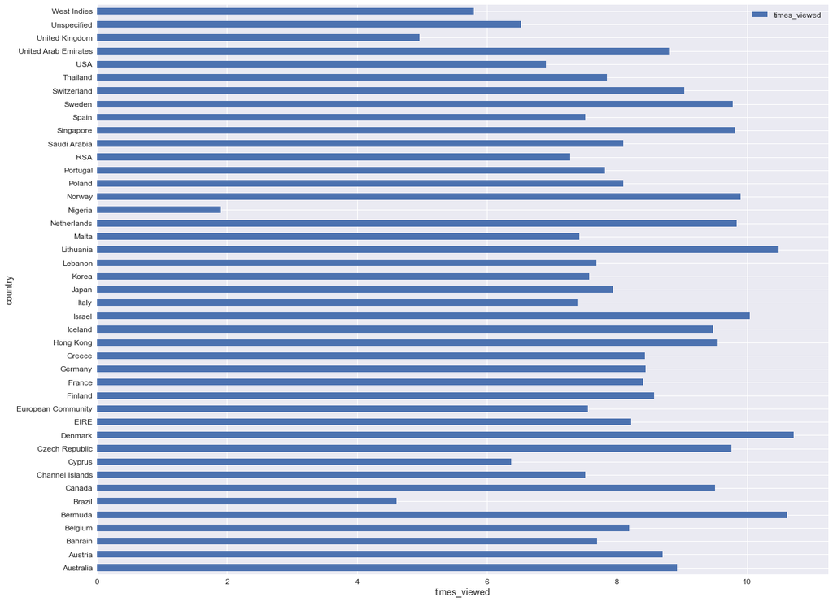

```python
x, y = 'country', 'times_viewed'
filename = os.path.join(IMG_DIR, "histogram_by-{}-{}_{}.png".format(x, y, today))
plot_horizontal_bar_chart(data_all, x, y, filename)

# Image(filename)
```

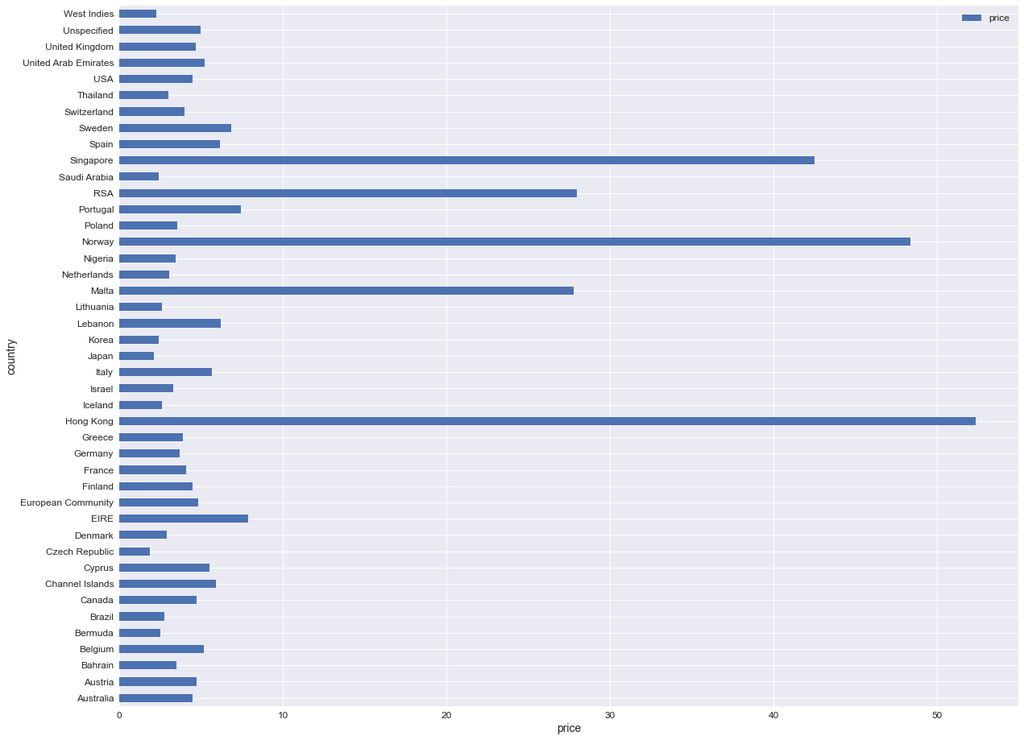

```python
x, y = 'country', 'price'
filename = os.path.join(IMG_DIR, "histogram_by-{}-{}_{}.png".format(x, y, today))
plot_horizontal_bar_chart(data_all, x, y, filename)

# Image(filename)
```

- Revenue of the top ten countries.

```
Ploting ts of revenue in portugal
-------------------------
```

```
Ploting ts of revenue in united_kingdom
-------------------------
```

```
Ploting ts of revenue in hong_kong
-------------------------
```

```
Ploting ts of revenue in eire
-------------------------
```

```
Ploting ts of revenue in spain
-------------------------
```

```
Ploting ts of revenue in france
-------------------------
```

```
Ploting ts of revenue in singapore
-------------------------
```

```
Ploting ts of revenue in all
-------------------------
```

```
Ploting ts of revenue in norway
-------------------------
```

```
Ploting ts of revenue in germany
-------------------------
```

```
Ploting ts of revenue in netherlands
-------------------------
```

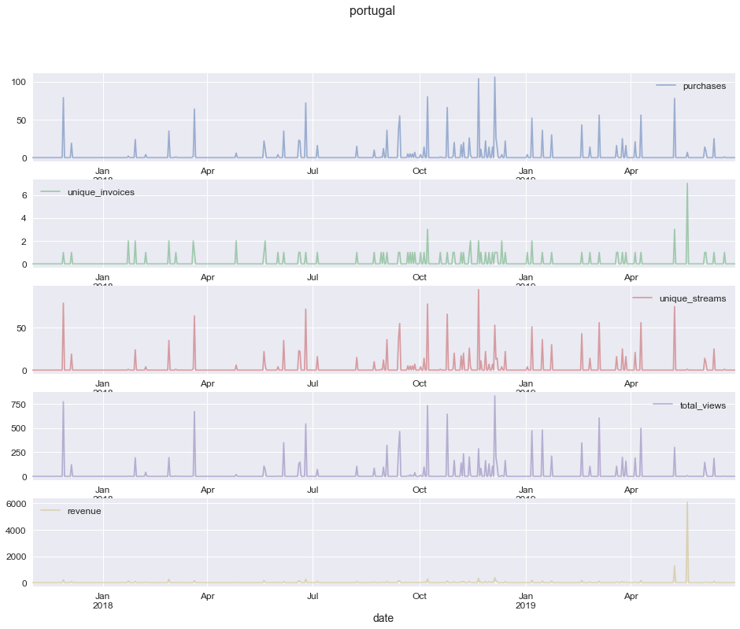

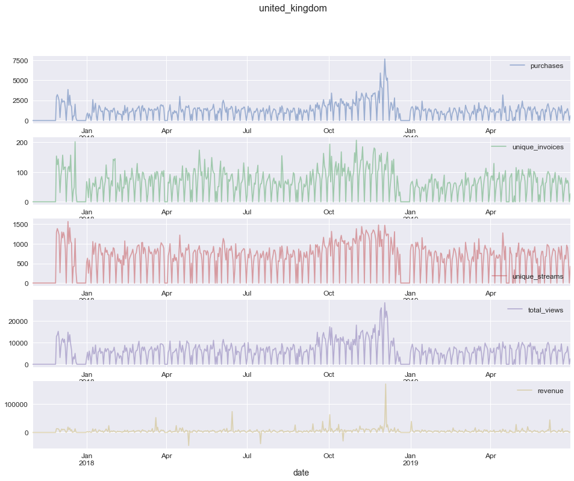

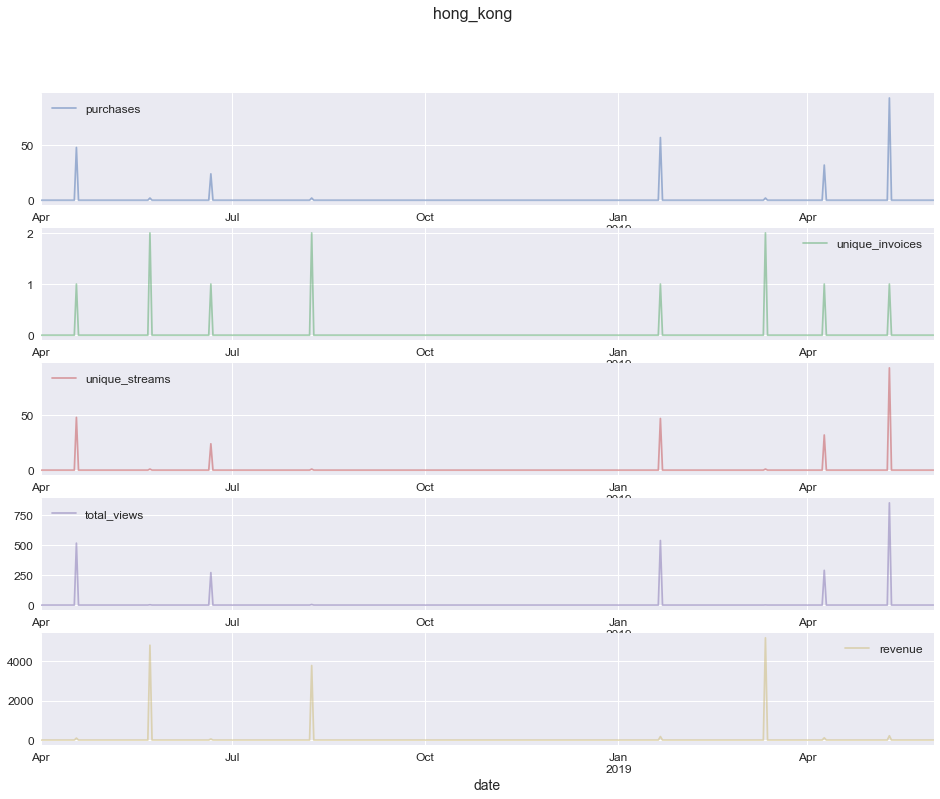

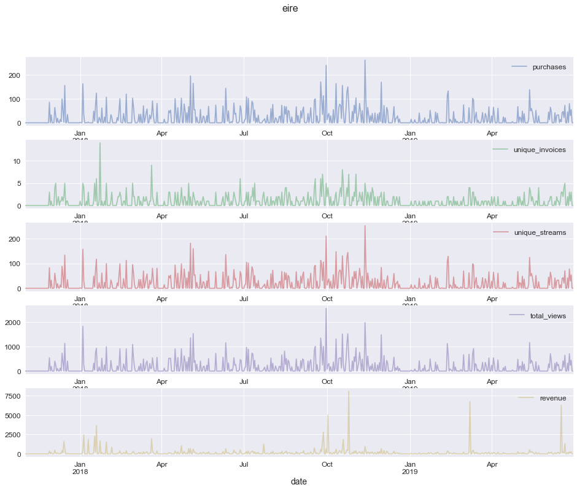

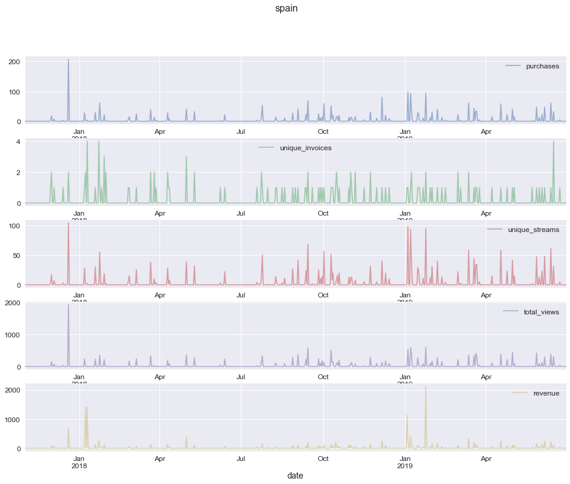

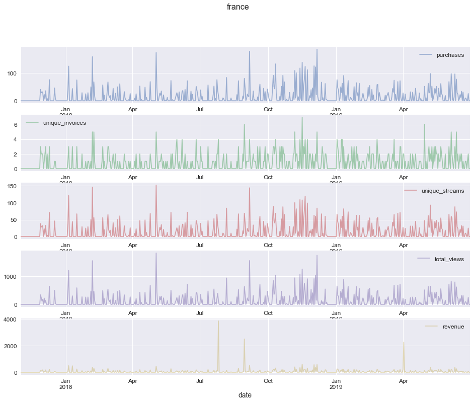

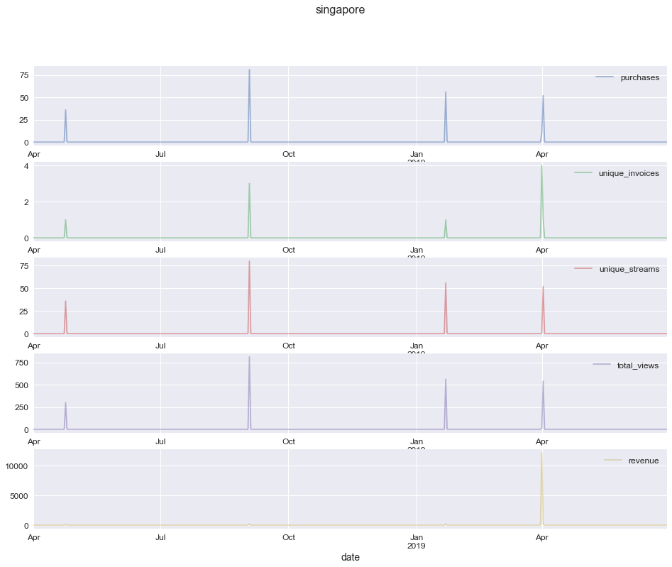

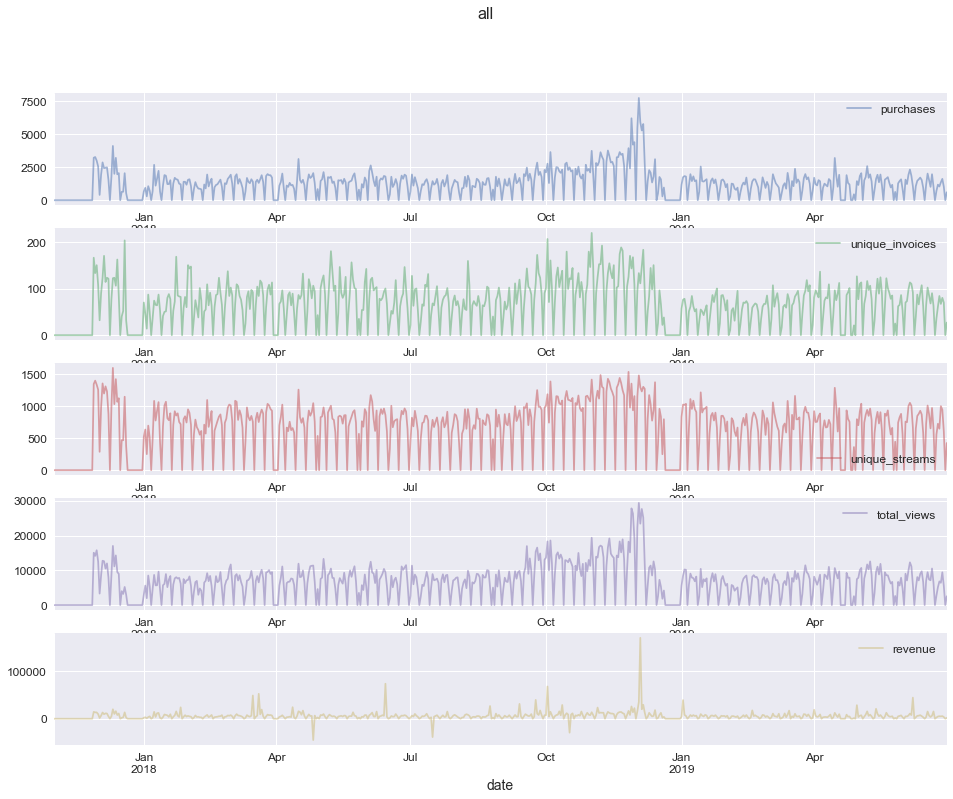

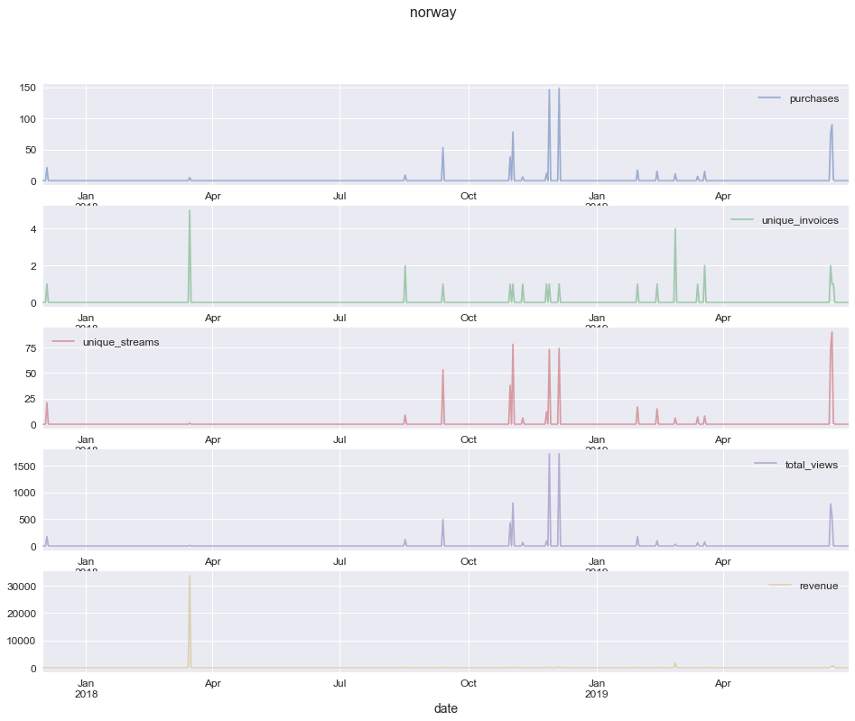

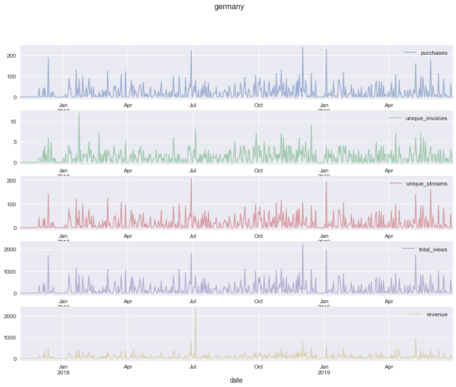

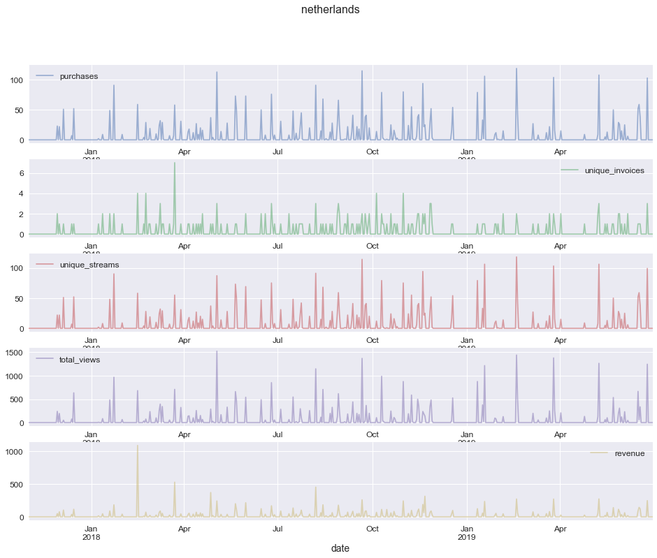

```python
cols_plot = ['purchases','unique_invoices',
             'unique_streams','total_views','revenue']
cols_str = "-".join(col for col in cols_plot)

for country, ts in ts_dict.items():
    filename = os.path.join(IMG_DIR, "ts_-{}-{}_{}.png".format(country, cols_str, today))
    print("Ploting ts of revenue in {}\n{}".format(country, "-"*25))
    plot_ts(ts, cols_plot, title=country, filename=filename)
```

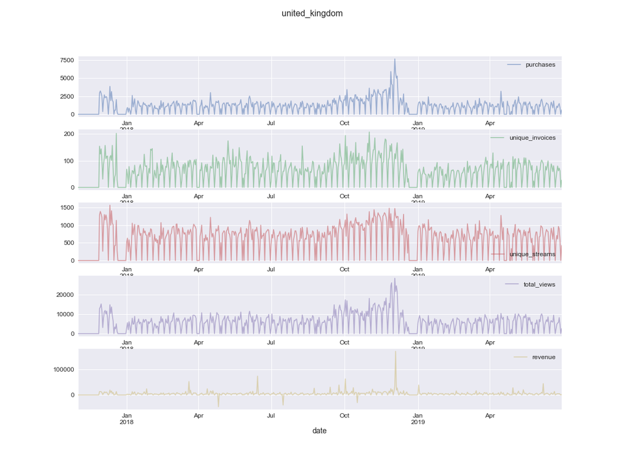

```python
# We visualize the ts of the top country
country = 'united_kingdom'
filename = os.path.join(IMG_DIR, "ts_-{}-{}_{}.png".format(country, cols_str, today))
Image(filename)
```

# PART 2: MODEL BUILDING AND SELECTION

## The story:

The business opportunity has been defined and you have come to an agreement with leadership with respect to appropriate wording and testable hypotheses. This part of the case study will focus on the next two stages in the enterprise workflow, namely data transformations and models. This part of the workflow will be treated slightly differently than previous case studies as these are time-series data, but the general procedure and best practices remain the same. These materials will provide the necessary guidance so that you can apply one of the supervised learning approaches that we have already discussed. However, you will also be encouraged to explore some of the time-series modeling tools available.

Time-series data are commonly encountered in data science. In particular, the field of finance, signal processing, weather and other fields regularly deal with data formatted in this way. The goal of this case study is time-series forecasting, which can be thought of as the use of a model to predict future values based on previously observed values. So we could try to predict purchases, number of views or the feature most closely related to our business opportunity, revenue.

## Tasks

- State the different modeling approaches that you will compare to address the business opportunity.
- Iterate on your suite of possible models by modifying data transformations, pipeline architectures, hyperparameters and other relevant factors.
- Re-train your model on all of the data using the selected approach and prepare it for deployment.
- Articulate your findings in a summary report.

```python
from scripts.model import *
```

## 1. MODEL APPROACHES

The goal is to predict the next point in time (reasonable value for next month's revenue).

Some of the most common tools for time-series analyses:

- Autoregressive models (AR)
- Vector autoregressive models (VAR)
- Univariate moving average models (ARMA)

In this project, we will use an approach of data aggregation (of previous time windows) to train several supervised regression approaches to predict the next 30-day window revenue.

## - Random Forest Regressor

## 2. MODEL ITERATIONS

Starting with the data from the country of most revenue:

```python
# We use helper function engineer_features with ts_all dataframe
ts_uk = ts_all['united_kingdom']
print(ts_uk.shape)
```

```
(607, 7)
```

### Feature engineering

For each day, the following features are captured:

For X (feature matrix)

- Sum of the revenue of the previous 7, 14, 28, 70 days.
- The sum of the previous year data (capture monthly trend)
- Non-revenue features from last month: mean of `recent_invoices` and `recent_views`.

For y (the predicted variable):

- Sum of the revenue for the next 30 days.

```python
X, y, dates = engineer_features(ts_uk)

print(X.shape)
X.head()
```

```
(549, 7)
```

|  | previous_7 | previous_14 | previous_28 | previous_70 | previous_year | recent_invoices | recent_views |
| --- | --- | --- | --- | --- | --- | --- | --- |
| 0 | 13281.12 | 13281.12 | 13281.12 | 13281.12 | 0.0 | 5.500000 | 461.500000 |
| 1 | 26504.09 | 26504.09 | 26504.09 | 26504.09 | 0.0 | 9.620690 | 916.275862 |
| 2 | 39445.59 | 39445.59 | 39445.59 | 39445.59 | 0.0 | 14.100000 | 1393.833333 |
| 3 | 48608.66 | 48608.66 | 48608.66 | 48608.66 | 0.0 | 17.433333 | 1782.233333 |
| 4 | 49871.94 | 49871.94 | 49871.94 | 49871.94 | 0.0 | 18.466667 | 1885.600000 |

### Model training (using part of UK's ts data)

- Split data in train/test (0.25 test, 0.75 train)
- Use GridSearch cross-validation to train a Random Regressor model (using aggregated features to predict y, next 30-day revenue).

```python
# Train model on a data sampel

n_samples = int(np.round(0.3 * X.shape[0]))
subset_indices = np.random.choice(np.arange(X.shape[0]),n_samples,
                                          replace=False).astype(int)

mask = np.in1d(np.arange(y.size),subset_indices)
y=y[mask]
X=X[mask]
dates=dates[mask]
print('... selected subset of {} for model training'.format(n_samples))

# Train a random forest model
X_train, X_test, y_train, y_test = train_test_split(X, y, test_size=0.25,
                                                        shuffle=True, random_state=42)

param_grid_rf = {'rf__criterion': ['mse','mae'],
                 'rf__n_estimators': [10,15,20,25]}

pipe_rf = Pipeline(steps=[('scaler', StandardScaler()),
                          ('rf', RandomForestRegressor())])

grid = GridSearchCV(pipe_rf, param_grid=param_grid_rf, cv=5, n_jobs=-1)
grid.fit(X_train, y_train)
y_pred = grid.predict(X_test)
eval_rmse =  round(np.sqrt(mean_squared_error(y_test,y_pred)))
print('... training model RMSE: {}'.format(eval_rmse))

print('...  retraining model using with the whole sample data')
grid.fit(X, y)
```

```
... selected subset of 165 for model training
... training model RMSE: 33884
...  retraining model using with the whole sample data
```

```
GridSearchCV(cv=5,
             estimator=Pipeline(steps=[('scaler', StandardScaler()),
                                       ('rf', RandomForestRegressor())]),
             n_jobs=-1,
             param_grid={'rf__criterion': ['mse', 'mae'],
                         'rf__n_estimators': [10, 15, 20, 25]})
```

```python
# Automatize with function: for 'united_kindgom' and 'all'

## Train model for UK and all
model_train(DATA_DIR, test=True)
```

```
... test flag on
...... subseting data
...... subseting countries
... loading ts data from files
... saving test version of model: models/test-united_kingdom-0_1.joblib
... saving test version of model: models/test-all-0_1.joblib
```

```python
## Load saved model
grid = joblib.load('models/test-united_kingdom-0_1.joblib')
y_pred = grid.predict(X_test)
eval_rmse =  round(np.sqrt(mean_squared_error(y_test,y_pred)))
print('... training model RMSE: {}'.format(eval_rmse))
```

```
... training model RMSE: 37713
```

We see that the RMSE is changing over model iterations.

```python
## Check different versions
log_file = pd.read_csv(os.path.join('logs',
                             'train-test-united_kingdom.log'))

display(log_file)
```

|  | unique_id | timestamp | tag | smodel | test_data | x_shape | eval_test | model_version | model_version_note | runtime |
| --- | --- | --- | --- | --- | --- | --- | --- | --- | --- | --- |
| 0 | 63bd967f-e8c7-4ba5-a58f-ed3b503b7fb9 | 1.621014e+09 | united_kingdom | rf | True | ('2017-12-07', '2019-05-30') | {'rmse': 36901} | 0.1 | supervised learning model for time-series | 000:00:02 |

## 3. Re-train with all data

```python
## Train model on all data ('sl', supervised learning)

model_train(DATA_DIR, test=False)
```

```
... loading ts data from files
... saving model: models/sl-portugal-0_1.joblib
... saving model: models/sl-united_kingdom-0_1.joblib
... saving model: models/sl-hong_kong-0_1.joblib
... saving model: models/sl-eire-0_1.joblib
... saving model: models/sl-spain-0_1.joblib
... saving model: models/sl-france-0_1.joblib
... saving model: models/sl-singapore-0_1.joblib
... saving model: models/sl-all-0_1.joblib
... saving model: models/sl-norway-0_1.joblib
... saving model: models/sl-germany-0_1.joblib
... saving model: models/sl-netherlands-0_1.joblib
```

All these functionalities are implemented in `model.py` script.

```python
# Test predict: of all countries
country='all'
year='2018'
month='01'
day='05'
result = model_predict(country,year,month,day)
print(result)
```

```
...Using all data and models from cs-train/ts-* and models/sl-*
... loading ts data from files
{'y_pred': array([184414.794]), 'y_proba': None}
```

## 4. Summary report

```python
log_list = glob.glob(os.path.join(LOG_DIR, "train-*.log"))

train_logs = pd.DataFrame()

for f in log_list:
    log = pd.read_csv(f)
    train_logs= pd.concat([train_logs, log], axis=0, ignore_index=True)

print("... {} models where trained".format(train_logs.shape[0]))
display(train_logs)
```

```
... 13 models where trained
```

|  | unique_id | timestamp | tag | smodel | test_data | x_shape | eval_test | model_version | model_version_note | runtime |
| --- | --- | --- | --- | --- | --- | --- | --- | --- | --- | --- |
| 0 | 49871ff5-5b5f-41c6-a8ad-99772e3101a8 | 1.621014e+09 | all | rf | True | ('2017-12-02', '2019-05-31') | {'rmse': 49038} | 0.1 | supervised learning model for time-series | 000:00:02 |
| 1 | b1cf9514-56ea-4965-ab33-4d422433cd98 | 1.621014e+09 | portugal | rf | False | ('2017-11-29', '2019-05-31') | {'rmse': 235} | 0.1 | supervised learning model for time-series | 000:00:03 |
| 2 | ed75ca4d-5b3c-49ce-8f06-8f2aa5cf31d7 | 1.621014e+09 | spain | rf | False | ('2017-12-01', '2019-05-31') | {'rmse': 234} | 0.1 | supervised learning model for time-series | 000:00:03 |
| 3 | 93be43b5-78cd-4042-95c3-61d74a67a51f | 1.621014e+09 | germany | rf | False | ('2017-11-29', '2019-05-31') | {'rmse': 497} | 0.1 | supervised learning model for time-series | 000:00:03 |
| 4 | af72ecd7-08e2-46d4-9f1d-e58b41b71ec7 | 1.621014e+09 | norway | rf | False | ('2017-12-05', '2019-05-11') | {'rmse': 65} | 0.1 | supervised learning model for time-series | 000:00:02 |
| 5 | dd59d8bd-41c8-4626-beea-1dc0288c4e3d | 1.621014e+09 | singapore | rf | False | ('2018-04-25', '2019-05-12') | {'rmse': 3679} | 0.1 | supervised learning model for time-series | 000:00:01 |
| 6 | 438ddf57-4632-4cf0-abe2-35d1ea9e32ed | 1.621014e+09 | hong_kong | rf | False | ('2018-04-19', '2019-05-01') | {'rmse': 852} | 0.1 | supervised learning model for time-series | 000:00:01 |
| 7 | 45547a6c-ea3c-4715-9ef9-427436ca0d28 | 1.621014e+09 | eire | rf | False | ('2017-11-29', '2019-05-31') | {'rmse': 1556} | 0.1 | supervised learning model for time-series | 000:00:04 |
| 8 | 63bd967f-e8c7-4ba5-a58f-ed3b503b7fb9 | 1.621014e+09 | united_kingdom | rf | True | ('2017-12-07', '2019-05-30') | {'rmse': 36901} | 0.1 | supervised learning model for time-series | 000:00:02 |
| 9 | 9559b62e-e5e8-4963-b70a-e7fa9a292d0e | 1.621014e+09 | france | rf | False | ('2017-11-29', '2019-05-31') | {'rmse': 556} | 0.1 | supervised learning model for time-series | 000:00:03 |
| 10 | 868f53e4-90c0-4708-9c8e-41ce21b5d781 | 1.621014e+09 | united_kingdom | rf | False | ('2017-11-29', '2019-05-31') | {'rmse': 16202} | 0.1 | supervised learning model for time-series | 000:00:03 |
| 11 | 6ef4638d-1c16-4044-8478-abbe4e9f4b3a | 1.621014e+09 | all | rf | False | ('2017-11-29', '2019-05-31') | {'rmse': 17479} | 0.1 | supervised learning model for time-series | 000:00:03 |
| 12 | fc28d690-277e-400e-9dd6-038a02710489 | 1.621014e+09 | netherlands | rf | False | ('2017-11-30', '2019-05-31') | {'rmse': 134} | 0.1 | supervised learning model for time-series | 000:00:03 |

We see that there are disparities in the error rates between countries (having UK and the data from all countries `all` the highest error rate).

```python
# Get test error values
train_logs['rmse'] = train_logs['eval_test'].apply(lambda x: ast.literal_eval(x)['rmse'])
train_logs.head()
```

|  | unique_id | timestamp | tag | smodel | test_data | x_shape | eval_test | model_version | model_version_note | runtime | rmse |
| --- | --- | --- | --- | --- | --- | --- | --- | --- | --- | --- | --- |
| 0 | 49871ff5-5b5f-41c6-a8ad-99772e3101a8 | 1.621014e+09 | all | rf | True | ('2017-12-02', '2019-05-31') | {'rmse': 49038} | 0.1 | supervised learning model for time-series | 000:00:02 | 49038 |
| 1 | b1cf9514-56ea-4965-ab33-4d422433cd98 | 1.621014e+09 | portugal | rf | False | ('2017-11-29', '2019-05-31') | {'rmse': 235} | 0.1 | supervised learning model for time-series | 000:00:03 | 235 |
| 2 | ed75ca4d-5b3c-49ce-8f06-8f2aa5cf31d7 | 1.621014e+09 | spain | rf | False | ('2017-12-01', '2019-05-31') | {'rmse': 234} | 0.1 | supervised learning model for time-series | 000:00:03 | 234 |
| 3 | 93be43b5-78cd-4042-95c3-61d74a67a51f | 1.621014e+09 | germany | rf | False | ('2017-11-29', '2019-05-31') | {'rmse': 497} | 0.1 | supervised learning model for time-series | 000:00:03 | 497 |
| 4 | af72ecd7-08e2-46d4-9f1d-e58b41b71ec7 | 1.621014e+09 | norway | rf | False | ('2017-12-05', '2019-05-11') | {'rmse': 65} | 0.1 | supervised learning model for time-series | 000:00:02 | 65 |

```
... 11 models where trained with all data
```

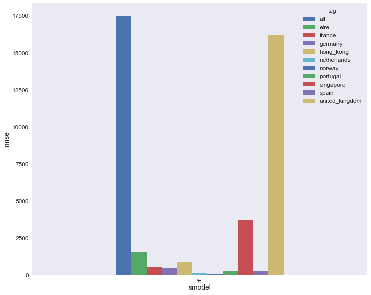

```python
# Select from all data
train_logs_all = train_logs.loc[train_logs.test_data != True,:]
print("... {} models where trained with all data".format(train_logs_all.shape[0]))

filename = os.path.join(IMG_DIR, 'train_rmse.png')
plot_multiple_bar_graph(train_logs_all, 'smodel', 'rmse', 'tag', filename)
```

## 3. MODEL DEPLOYMENT

# PART 3: MODEL PRODUCTION

## Tasks

- Build a draft version of an API with train, predict, and logfile endpoints.
- Using Docker, bundle your API, model, and unit tests.
- Using test-driven development iterate on your API in a way that anticipates scale, load, and drift.
- Create a post-production analysis script that investigates the relationship between model performance and the business metric.
- Articulate your summarized findings in a final report.

## Getting started

There are three tasks in the pieces to the final part of the case study:

- Ready your model for deployment.
- Query your API with new data and test your monitoring tools.
- Compare your results to the gold standard.

Note: In reality your model would re-train itself at some cadence (e.g. nightly or weekly). If your systems is capable of this you should demonstrate this capacity as part of the deliverable. This is not a requirement of the model for this assignment, but it is an important aspect of model deployment to keep in mind.

## 1. Build API

Build an API with train, predict, and logfile endpoints.

`app.py` contains endpoints for *train, predict, log*

Run from project directory (./ai-workflow-capstone-master) and run

> $ python app.py

Running on [http://0.0.0.0:8080/], check it works and stop the server. (Run in Docker).

!python app.py

```python
X_new_data = {}
X_new_data['country'] = ['all']
X_new_data['year'] = ['2018']
X_new_data['month'] = ['01']
X_new_data['day'] = ['05']
X_new = pd.DataFrame(X_new_data)
X_new.head()
```

|  | country | year | month | day |
| --- | --- | --- | --- | --- |
| 0 | all | 2018 | 01 | 05 |

```python
## data needs to be in dict format for JSON
query = X_new.loc[0,:].to_dict()
request_json = {'query': query, 'type':'dict'}

## test the Flask API
port = 8080
r = requests.post('http://0.0.0.0:{}/predict'.format(port),
                  json=request_json)

response = json.loads(r.text.replace("\n",""))
print(response)
```

```
{'y_pred': [184414.79399999994], 'y_proba': None}
```

```python
np.round(response['y_pred'], 3)
```

```
array([184414.794])
```

Checked that it matches with prediction in Part 2 for `country='all'`

```
... loading ts data from files
      {'y_pred': array([184414.794]), 'y_proba': None}
```

## 2. Dockerize

Docker to bundle API, model, unit tests.

Docker image created in `Dockerfile`

Step one: open Docker engine and build the image (from the directory that was created with this notebook)

```
~$ cd ai-workflow-capstone-master
    ~$ docker build -t capstone-master .
```

Check that the image is there.

```
~$ docker image ls
```

Run the container

```
docker run -p 4000:8080 capstone-master
```

Test the running app

First go to http://0.0.0.0:4000/ to ensure the app is running and accessible.

```python
## test the Docker API
port = 4000
r = requests.post('http://0.0.0.0:{}/predict'.format(port),json=query)

response = json.loads(r.text.replace("\n",""))
print(response)
```

## 3. Unit tests

Run first

```
$ python app.py
```

```python
!python run-tests.py
```

```
........... loading ts data from files
... saving model: models/sl-portugal-0_1.joblib
... saving model: models/sl-united_kingdom-0_1.joblib
... saving model: models/sl-hong_kong-0_1.joblib
... saving model: models/sl-eire-0_1.joblib
... saving model: models/sl-spain-0_1.joblib
... saving model: models/sl-france-0_1.joblib
... saving model: models/sl-singapore-0_1.joblib
... saving model: models/sl-all-0_1.joblib
... saving model: models/sl-norway-0_1.joblib
... saving model: models/sl-germany-0_1.joblib
... saving model: models/sl-netherlands-0_1.joblib
.... loading ts data from files
....Using all data and models from cs-train/ts-* and models/sl-*
... loading ts data from files
.
----------------------------------------------------------------------
Ran 11 tests in 93.263s

OK
```

## 4. Post-production analysis

Use ts-production data to see how well it performs.

```python
PROD_DIR = os.path.join(".","cs-production")

# Load production data and all 'sl' models
prod_data, models = model_load(data_dir=PROD_DIR, training=False)
```

```
... processing data for loading
```

```python
prod_data['united_kingdom'].keys()
```

```
dict_keys(['X', 'y', 'dates'])
```

# Load prod_data as time series for EDA prod_data_ts = import_csv_to_ts(PROD_DIR) prod_data_ts['portugal']

```python
## PREDICT ON PROD_DATA
results = {}

for country, df in prod_data.items():
    if country in list(models.keys()):
        print("... predicting on {}\n{}".format(country,"-"*35))
        X = df['X']
        y = df['y']
        dates = df['dates']
        if len(X)==0:
            print("empty file on {}".format(country))
            continue

        y_pred = []
        for i, day in enumerate(dates):
            dd = day.astype('datetime64[D]').item()
            year, month, day = dd.year, dd.month, dd.day
            y_pred_i = model_predict(country, str(year), str(month), str(day),
                                     all_models=models,
                                     all_data=prod_data)
            y_pred.append(y_pred_i['y_pred'][0])

        eval_rmse =   round(np.sqrt(mean_squared_error(y,y_pred)))

        results[country] = {'rmse': [eval_rmse]*len(y),
                            'date': dates, 'y': y, 'y_pred':y_pred}
    else:
        print("... no model trained on {}\n{}".format(country,"-"*35))
        pass
```

```
... predicting on all
-----------------------------------
... predicting on united_kingdom
-----------------------------------
... predicting on france
-----------------------------------
... predicting on germany
-----------------------------------
... predicting on eire
-----------------------------------
... predicting on singapore
-----------------------------------
empty file on singapore
... predicting on hong_kong
-----------------------------------
... predicting on spain
-----------------------------------
... predicting on portugal
-----------------------------------
... no model trained on belgium
-----------------------------------
... predicting on netherlands
-----------------------------------
```

## 5. Findings

- In the plots, we see how the trends are to some extent captured by the models, but there are some issues (specially after the first predicted month, i.e., from October on).

```
Ploting ts of predictions in all
-------------------------
Ploting ts of predictions in united_kingdom
-------------------------
Ploting ts of predictions in france
-------------------------
Ploting ts of predictions in germany
-------------------------
Ploting ts of predictions in eire
-------------------------
Ploting ts of predictions in hong_kong
-------------------------
Ploting ts of predictions in spain
-------------------------
Ploting ts of predictions in portugal
-------------------------
Ploting ts of predictions in netherlands
-------------------------
```

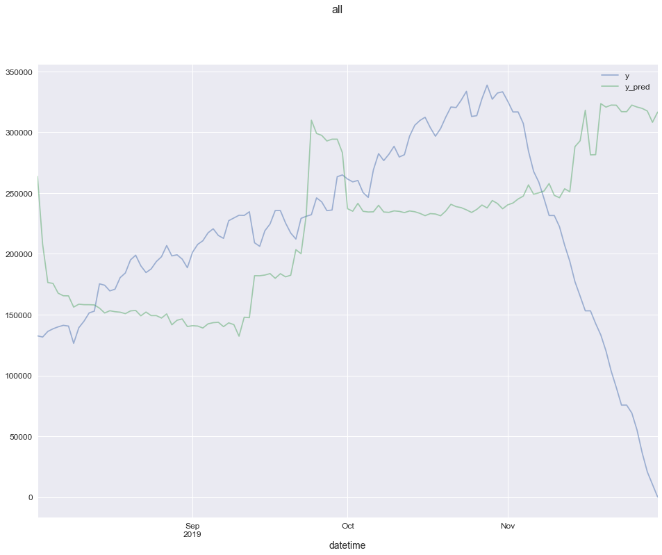

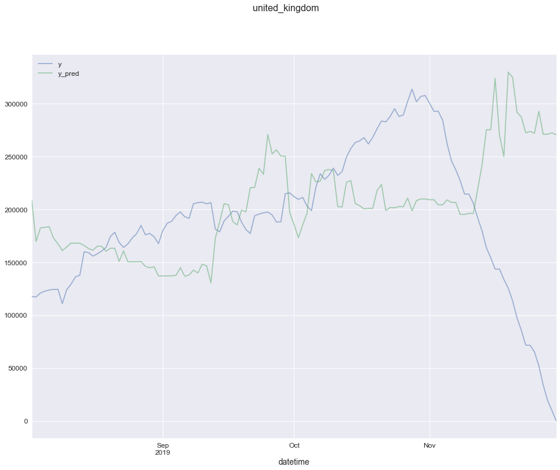

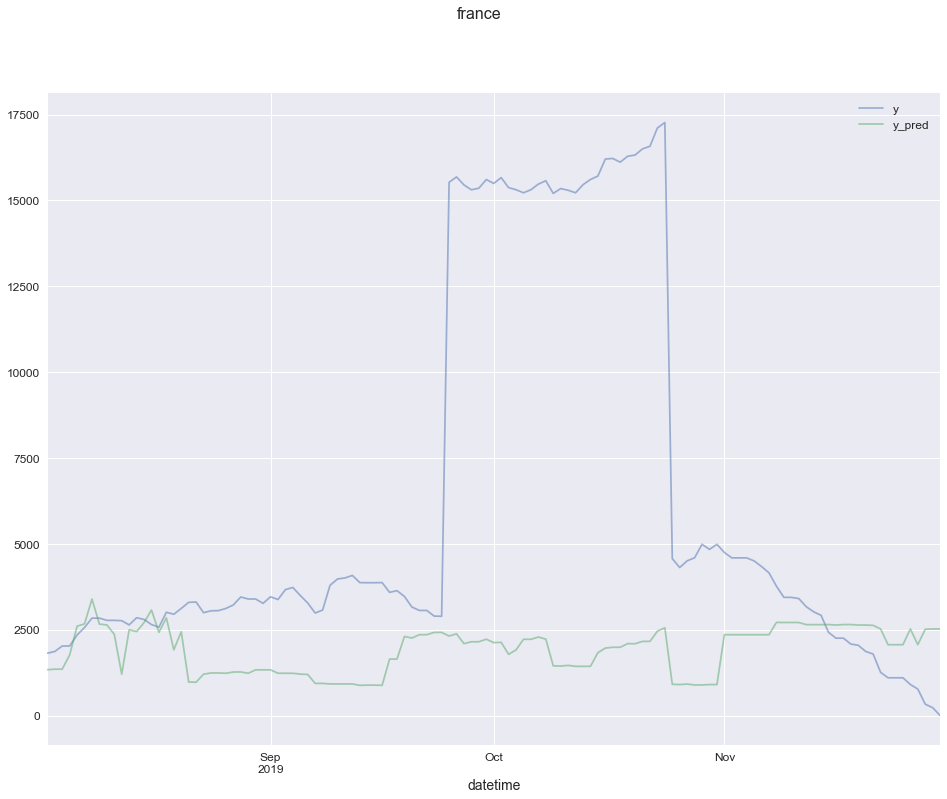

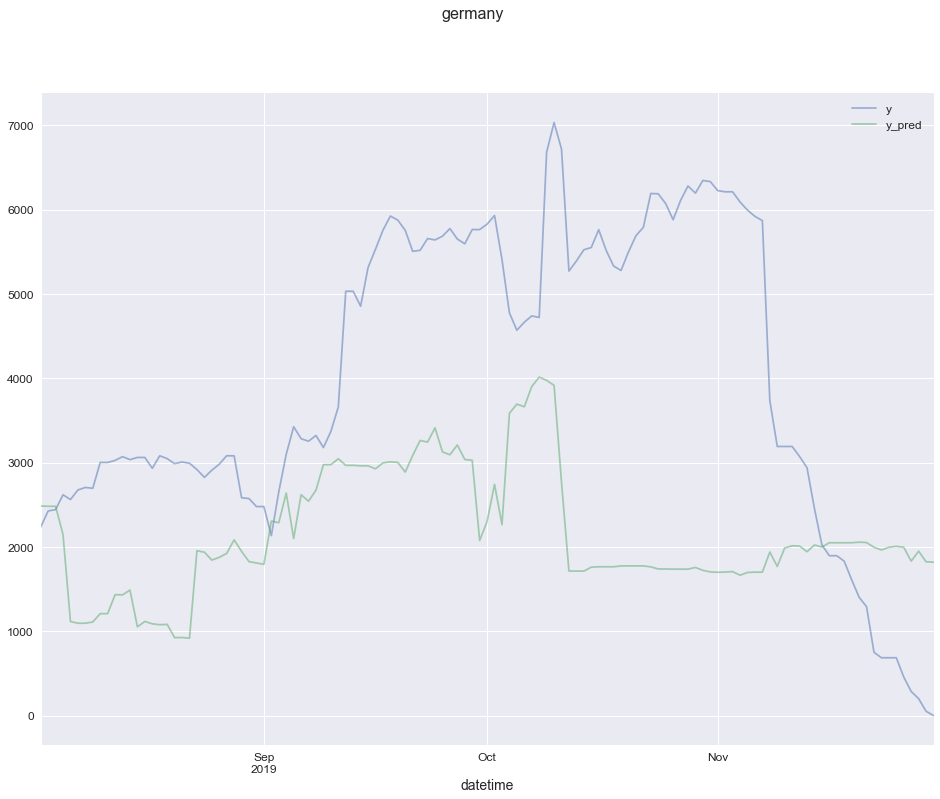

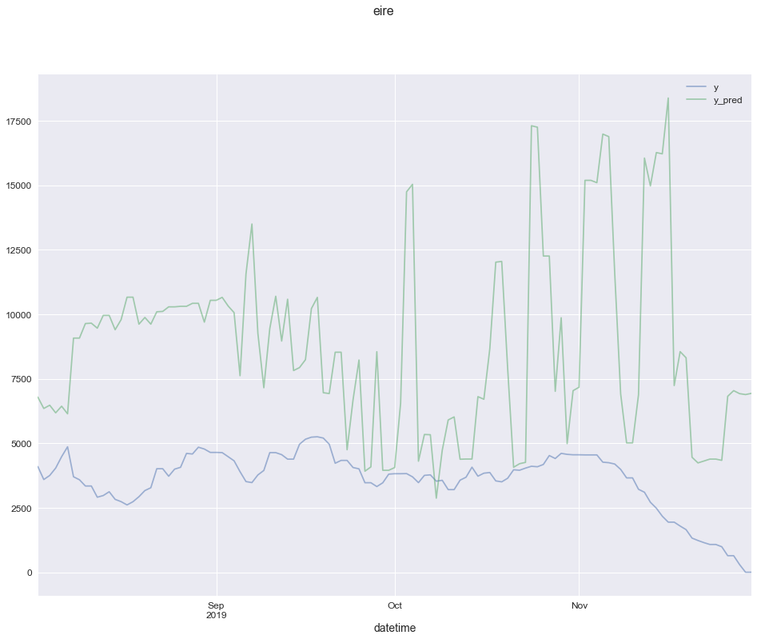

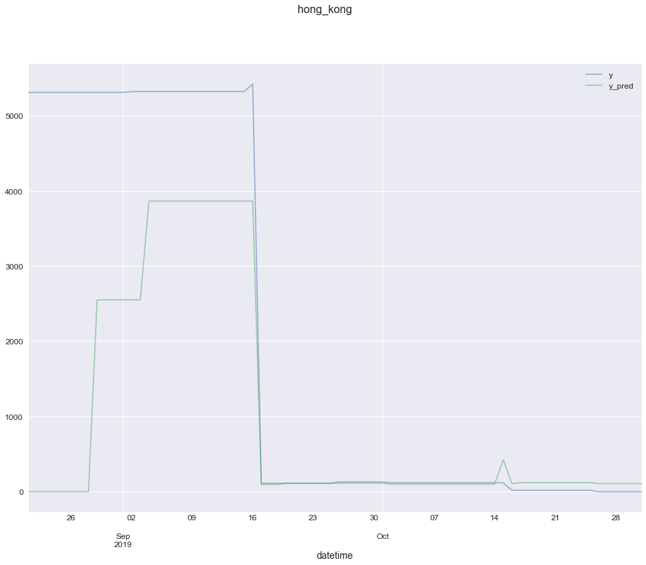

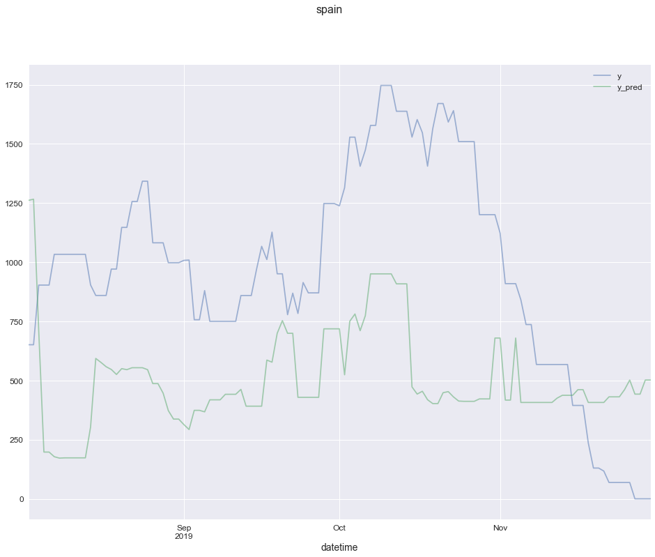

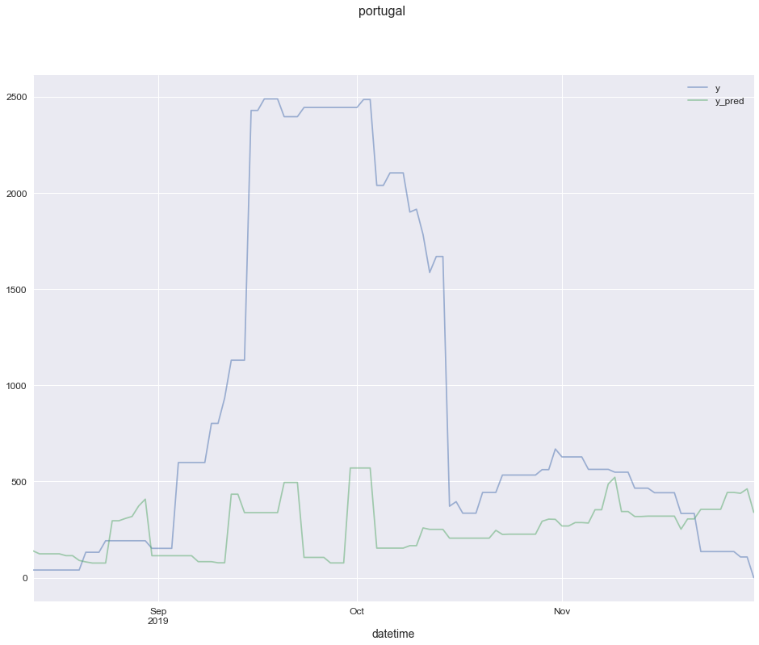

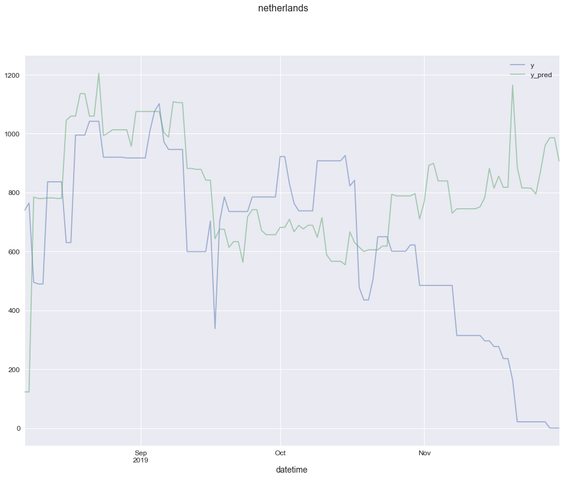

```python
## PLOT RESULTS
cols_plot = ['y', 'y_pred']
cols_str = "-".join(col for col in cols_plot)

for country, res in results.items():
    # Convert to ts
    res_ts = convert_df_to_ts(pd.DataFrame(res),'date')
    #print(res_ts.head())

    # Plot
    filename = os.path.join(IMG_DIR, "prod_ts_-{}-{}_{}.png".format(country, cols_str, today))
    print("Ploting ts of predictions in {}\n{}".format(country, "-"*25))
    plot_ts(res_ts, cols_plot, title=country, filename=filename, join=False)
```